# Projet 9. Produisez une étude de marché avec R ou Python

[figure not shown]

### Réalisée par: Thi Tuong Le

## 1. Import libraries

```python
import pandas as pd
import numpy as np
import seaborn as sns
import matplotlib as plt
```

## 2. Travail d'analyse

```python
# get cwd
import os
os.getcwd()
```

```
'/Users/lethituong/Desktop/Data Analyst/OpenClassrooms projects/P9-Produisez une étude de marché avec R ou Python/DAN-P9-data'
```

```python
df_final = pd.read_csv('df_final.csv')
```

```python
df_final
```

|  | Unnamed: 0 | Zone | pop2017 | %pop change 2006-2017 | RatioProtVol% | DispoAliVolKcal | DispoAliProtVol | ('Valeur', 'PIB par habitant') | ('Valeur', 'Stabilité politique') | distance(km) |
| --- | --- | --- | --- | --- | --- | --- | --- | --- | --- | --- |
| 0 | 0 | Afghanistan | 36296.113 | 37.313380 | 10.50 | 6.0 | 0.63 | 2058.4 | -2.80 | 5590.381 |
| 1 | 1 | Afrique du Sud | 57009.756 | 17.571442 | 9.82 | 149.0 | 14.63 | 12701.3 | -0.28 | 8692.812 |
| 2 | 2 | Albanie | 2884.169 | -5.839072 | 7.53 | 59.0 | 4.44 | 12771.0 | 0.38 | 1603.534 |
| 3 | 3 | Algérie | 41389.189 | 23.031974 | 8.88 | 24.0 | 2.13 | 11737.4 | -0.92 | 1340.390 |
| 4 | 4 | Allemagne | 82658.409 | 1.455935 | 11.03 | 67.0 | 7.39 | 52952.9 | 0.59 | 880.187 |
| ... | ... | ... | ... | ... | ... | ... | ... | ... | ... | ... |
| 164 | 164 | Émirats arabes unis | 9487.203 | 78.997954 | 10.14 | 88.0 | 8.92 | 67183.6 | 0.62 | 5249.535 |
| 165 | 165 | Équateur | 16785.361 | 19.389022 | 7.43 | 87.0 | 6.46 | 11617.9 | -0.07 | 9367.098 |
| 166 | 166 | États-Unis d'Amérique | 325084.756 | 9.177150 | 9.08 | 220.0 | 19.98 | 60109.7 | 0.34 | 6169.154 |
| 167 | 167 | Éthiopie | 106399.924 | 35.559944 | 12.00 | 2.0 | 0.24 | 2021.6 | -1.68 | 5582.502 |
| 168 | 168 | Îles Salomon | 636.039 | 32.211201 | 8.16 | 19.0 | 1.55 | 2663.9 | 0.20 | 15178.200 |

169 rows × 10 columns

```python
len(df_final)
```

```
169
```

```python
df = df_final.dropna()
```

```python
df
```

|  | Unnamed: 0 | Zone | pop2017 | %pop change 2006-2017 | RatioProtVol% | DispoAliVolKcal | DispoAliProtVol | ('Valeur', 'PIB par habitant') | ('Valeur', 'Stabilité politique') | distance(km) |
| --- | --- | --- | --- | --- | --- | --- | --- | --- | --- | --- |
| 0 | 0 | Afghanistan | 36296.113 | 37.313380 | 10.50 | 6.0 | 0.63 | 2058.4 | -2.80 | 5590.381 |
| 1 | 1 | Afrique du Sud | 57009.756 | 17.571442 | 9.82 | 149.0 | 14.63 | 12701.3 | -0.28 | 8692.812 |
| 2 | 2 | Albanie | 2884.169 | -5.839072 | 7.53 | 59.0 | 4.44 | 12771.0 | 0.38 | 1603.534 |
| 3 | 3 | Algérie | 41389.189 | 23.031974 | 8.88 | 24.0 | 2.13 | 11737.4 | -0.92 | 1340.390 |
| 4 | 4 | Allemagne | 82658.409 | 1.455935 | 11.03 | 67.0 | 7.39 | 52952.9 | 0.59 | 880.187 |
| ... | ... | ... | ... | ... | ... | ... | ... | ... | ... | ... |
| 164 | 164 | Émirats arabes unis | 9487.203 | 78.997954 | 10.14 | 88.0 | 8.92 | 67183.6 | 0.62 | 5249.535 |
| 165 | 165 | Équateur | 16785.361 | 19.389022 | 7.43 | 87.0 | 6.46 | 11617.9 | -0.07 | 9367.098 |
| 166 | 166 | États-Unis d'Amérique | 325084.756 | 9.177150 | 9.08 | 220.0 | 19.98 | 60109.7 | 0.34 | 6169.154 |
| 167 | 167 | Éthiopie | 106399.924 | 35.559944 | 12.00 | 2.0 | 0.24 | 2021.6 | -1.68 | 5582.502 |
| 168 | 168 | Îles Salomon | 636.039 | 32.211201 | 8.16 | 19.0 | 1.55 | 2663.9 | 0.20 | 15178.200 |

162 rows × 10 columns

```python
len(df)
```

```
162
```

```python
# Changer le nom pour les colonnes
df.rename(columns={"('Valeur', 'PIB par habitant')":"PIB/hab",
                               "('Valeur', 'Stabilité politique')":"stab_poli"},
                     inplace=True)
```

```python
df.head()
```

|  | Unnamed: 0 | Zone | pop2017 | %pop change 2006-2017 | RatioProtVol% | DispoAliVolKcal | DispoAliProtVol | PIB/hab | stab_poli | distance(km) |
| --- | --- | --- | --- | --- | --- | --- | --- | --- | --- | --- |
| 0 | 0 | Afghanistan | 36296.113 | 37.313380 | 10.50 | 6.0 | 0.63 | 2058.4 | -2.80 | 5590.381 |
| 1 | 1 | Afrique du Sud | 57009.756 | 17.571442 | 9.82 | 149.0 | 14.63 | 12701.3 | -0.28 | 8692.812 |
| 2 | 2 | Albanie | 2884.169 | -5.839072 | 7.53 | 59.0 | 4.44 | 12771.0 | 0.38 | 1603.534 |
| 3 | 3 | Algérie | 41389.189 | 23.031974 | 8.88 | 24.0 | 2.13 | 11737.4 | -0.92 | 1340.390 |
| 4 | 4 | Allemagne | 82658.409 | 1.455935 | 11.03 | 67.0 | 7.39 | 52952.9 | 0.59 | 880.187 |

```python
df.set_index('Zone', inplace = True)
df
```

| Zone | Unnamed: 0 | pop2017 | %pop change 2006-2017 | RatioProtVol% | DispoAliVolKcal | DispoAliProtVol | PIB/hab | stab_poli | distance(km) |
| --- | --- | --- | --- | --- | --- | --- | --- | --- | --- |
| Afghanistan | 0 | 36296.113 | 37.313380 | 10.50 | 6.0 | 0.63 | 2058.4 | -2.80 | 5590.381 |
| Afrique du Sud | 1 | 57009.756 | 17.571442 | 9.82 | 149.0 | 14.63 | 12701.3 | -0.28 | 8692.812 |
| Albanie | 2 | 2884.169 | -5.839072 | 7.53 | 59.0 | 4.44 | 12771.0 | 0.38 | 1603.534 |
| Algérie | 3 | 41389.189 | 23.031974 | 8.88 | 24.0 | 2.13 | 11737.4 | -0.92 | 1340.390 |
| Allemagne | 4 | 82658.409 | 1.455935 | 11.03 | 67.0 | 7.39 | 52952.9 | 0.59 | 880.187 |
| ... | ... | ... | ... | ... | ... | ... | ... | ... | ... |
| Émirats arabes unis | 164 | 9487.203 | 78.997954 | 10.14 | 88.0 | 8.92 | 67183.6 | 0.62 | 5249.535 |
| Équateur | 165 | 16785.361 | 19.389022 | 7.43 | 87.0 | 6.46 | 11617.9 | -0.07 | 9367.098 |
| États-Unis d'Amérique | 166 | 325084.756 | 9.177150 | 9.08 | 220.0 | 19.98 | 60109.7 | 0.34 | 6169.154 |
| Éthiopie | 167 | 106399.924 | 35.559944 | 12.00 | 2.0 | 0.24 | 2021.6 | -1.68 | 5582.502 |
| Îles Salomon | 168 | 636.039 | 32.211201 | 8.16 | 19.0 | 1.55 | 2663.9 | 0.20 | 15178.200 |

162 rows × 9 columns

- Zone: les pays
- pop2017: le population en 2017
- %pop change 2006-2017: Évolution de la population entre 2006 et 2017 (%)
- RatioProtVol%: Disponibilité en protéine animale par rapport à la disponibilité totale en protéine (%)
- DispoAliProtVol: Disponibilité totale en protéine de vollaile (g/pers/jour)
- DispoAliVolKcal: Disponibilité totale en kilocalorie (Kcal/pers/jour)
- PIB/hab: PIB par habitant en Parité de Pouvoir d'Achat référencée sur la valeur du dollar en 2017
- stab_poli: Indice sur la stabilité politique et l'absence de violence/terrorisme

```python
df1=df.drop(df.columns[0], axis=1)
```

```python
df1
```

| Zone | pop2017 | %pop change 2006-2017 | RatioProtVol% | DispoAliVolKcal | DispoAliProtVol | PIB/hab | stab_poli | distance(km) |
| --- | --- | --- | --- | --- | --- | --- | --- | --- |
| Afghanistan | 36296.113 | 37.313380 | 10.50 | 6.0 | 0.63 | 2058.4 | -2.80 | 5590.381 |
| Afrique du Sud | 57009.756 | 17.571442 | 9.82 | 149.0 | 14.63 | 12701.3 | -0.28 | 8692.812 |
| Albanie | 2884.169 | -5.839072 | 7.53 | 59.0 | 4.44 | 12771.0 | 0.38 | 1603.534 |
| Algérie | 41389.189 | 23.031974 | 8.88 | 24.0 | 2.13 | 11737.4 | -0.92 | 1340.390 |
| Allemagne | 82658.409 | 1.455935 | 11.03 | 67.0 | 7.39 | 52952.9 | 0.59 | 880.187 |
| ... | ... | ... | ... | ... | ... | ... | ... | ... |
| Émirats arabes unis | 9487.203 | 78.997954 | 10.14 | 88.0 | 8.92 | 67183.6 | 0.62 | 5249.535 |
| Équateur | 16785.361 | 19.389022 | 7.43 | 87.0 | 6.46 | 11617.9 | -0.07 | 9367.098 |
| États-Unis d'Amérique | 325084.756 | 9.177150 | 9.08 | 220.0 | 19.98 | 60109.7 | 0.34 | 6169.154 |
| Éthiopie | 106399.924 | 35.559944 | 12.00 | 2.0 | 0.24 | 2021.6 | -1.68 | 5582.502 |
| Îles Salomon | 636.039 | 32.211201 | 8.16 | 19.0 | 1.55 | 2663.9 | 0.20 | 15178.200 |

162 rows × 8 columns

# Utiliser le ACP pour faire!!!

```python
#Checking the correlation between variables
#corrMatrix = df1.corr()
#sns.set(rc = {'figure.figsize':(15,8)})
#sns.heatmap(corrMatrix, annot=True)
#plt.show()
```

```python
# préparation des données

X= df1
names = df1.index
nom_variable = df1.columns
```

```python
# Centrage et Reduction
from sklearn import decomposition
from sklearn import preprocessing
```

```python
std_scale=preprocessing.StandardScaler().fit(X)
X_scaled = std_scale.transform(X)
```

```python
X.head()
```

| Zone | pop2017 | %pop change 2006-2017 | RatioProtVol% | DispoAliVolKcal | DispoAliProtVol | PIB/hab | stab_poli | distance(km) |
| --- | --- | --- | --- | --- | --- | --- | --- | --- |
| Afghanistan | 36296.113 | 37.313380 | 10.50 | 6.0 | 0.63 | 2058.4 | -2.80 | 5590.381 |
| Afrique du Sud | 57009.756 | 17.571442 | 9.82 | 149.0 | 14.63 | 12701.3 | -0.28 | 8692.812 |
| Albanie | 2884.169 | -5.839072 | 7.53 | 59.0 | 4.44 | 12771.0 | 0.38 | 1603.534 |
| Algérie | 41389.189 | 23.031974 | 8.88 | 24.0 | 2.13 | 11737.4 | -0.92 | 1340.390 |
| Allemagne | 82658.409 | 1.455935 | 11.03 | 67.0 | 7.39 | 52952.9 | 0.59 | 880.187 |

```python
#Calcul des composantes principales
pca = decomposition.PCA(n_components=8)
```

```python
#Correspond aux 8 variables
pca.fit(X_scaled)
```

```
PCA(copy=True, iterated_power='auto', n_components=8, random_state=None,
    svd_solver='auto', tol=0.0, whiten=False)
```

```python
#Variance
print(pca.explained_variance_)
```

```
[2.86647932 1.68494314 1.04687975 0.86433551 0.76455279 0.5375334
 0.272198   0.01276753]
```

```python
print(pca.explained_variance_ratio_.cumsum())
```

```
[0.35609813 0.56541591 0.6954681  0.80284311 0.89782228 0.96459919
 0.99841391 1.        ]
```

```python
# Je crée une df qui affiche la variance expliquée pour chaque dimension.
variance = pd.DataFrame(
    {
        "Dimension" : ["Dim" + str(x + 1) for x in range(8)],
        "Variance expliquée" : pca.explained_variance_,
        "% variance expliquée" : np.round(pca.explained_variance_ratio_ * 100),
        "% cum. var. expliquée" : np.round(np.cumsum(pca.explained_variance_ratio_) * 100)
    }
)
variance
```

|  | Dimension | Variance expliquée | % variance expliquée | % cum. var. expliquée |
| --- | --- | --- | --- | --- |
| 0 | Dim1 | 2.866479 | 36.0 | 36.0 |
| 1 | Dim2 | 1.684943 | 21.0 | 57.0 |
| 2 | Dim3 | 1.046880 | 13.0 | 70.0 |
| 3 | Dim4 | 0.864336 | 11.0 | 80.0 |
| 4 | Dim5 | 0.764553 | 9.0 | 90.0 |
| 5 | Dim6 | 0.537533 | 7.0 | 96.0 |
| 6 | Dim7 | 0.272198 | 3.0 | 100.0 |
| 7 | Dim8 | 0.012768 | 0.0 | 100.0 |

```python
def display_scree_plot(pca):
    scree = pca.explained_variance_ratio_*100
    plt.bar(np.arange(len(scree))+1, scree)
    plt.plot(np.arange(len(scree))+1, scree.cumsum(),c="red",marker='o')
    plt.xlabel("rang de l'axe d'inertie")
    plt.ylabel("pourcentage d'inertie")
    plt.title("Eboulis des valeurs propres")
    plt.show(block=False)
```

```python
import matplotlib.pyplot as plt
```

```python
# Calcul des composantes principales
n_comp = 6   # correspond au nombre de variables
pca = decomposition.PCA(n_components=n_comp)
pca.fit(X_scaled)
```

```
PCA(copy=True, iterated_power='auto', n_components=6, random_state=None,
    svd_solver='auto', tol=0.0, whiten=False)
```

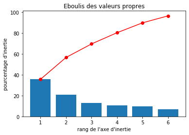

```python
display_scree_plot(pca)
```

```python
# Calcul des composantes principales
n_comp = 3   # correspond au nombre de Composantes principales
pca = decomposition.PCA(n_components=n_comp)
pca.fit(X_scaled)
```

```
PCA(copy=True, iterated_power='auto', n_components=3, random_state=None,
    svd_solver='auto', tol=0.0, whiten=False)
```

Eboulis des valeurs propres: A apprendre!!! https://openclassrooms.com/fr/courses/4525281-realisez-une-analyse-exploratoire-de-donnees/5280037-choisissez-le-nombre-de-composantes

**Résumer**

- Grace à l'ACP, on peut calculer le pourcentage de variance qui est captée par chaque axe.
- En additionnant ces pourcentages, on obtient la variance cumulée dont la somme totale est 100 %.
- La représentation graphique associée s'appelle l'éboulis des valeurs propres. C'est un graphique indispensable en ACP.
- Il n'y a pas de règle générale sur le nombre de plans à analyser.
- On applique toutefois souvent la méthode du coude pour établir ce nombre.
- Il arrive souvent de n'analyser que les 1, 2 ou 3 premiers plans factoriels.

```python
# Fonction qui me permet d'afficher mes cercles de corrélations
def display_circles(pcs, n_comp, pca, axis_ranks, labels=None, label_rotation=0, lims=None):
    for d1, d2 in axis_ranks: # On affiche les 3 premiers plans factoriels, donc les 6 premières composantes
        if d2 < n_comp:

            # initialisation de la figure
            fig, ax = plt.subplots(figsize=(8,8))

            # détermination des limites du graphique
            if lims is not None :
                xmin, xmax, ymin, ymax = lims
            elif pcs.shape[1] < 30 :
                xmin, xmax, ymin, ymax = -1, 1, -1, 1
            else :
                xmin, xmax, ymin, ymax = min(pcs[d1,:]), max(pcs[d1,:]), min(pcs[d2,:]), max(pcs[d2,:])

            # affichage des flèches
            # s'il y a plus de 30 flèches, on n'affiche pas le triangle à leur extrémité
            if pcs.shape[1] < 30 :
                plt.quiver(np.zeros(pcs.shape[1]), np.zeros(pcs.shape[1]),
                   pcs[d1,:], pcs[d2,:],
                   angles='xy', scale_units='xy', scale=1, color="orange")
                # (voir la doc : https://matplotlib.org/api/_as_gen/matplotlib.pyplot.quiver.html)
            else:
                lines = [[[0,0],[x,y]] for x,y in pcs[[d1,d2]].T]
                ax.add_collection(LineCollection(lines, axes=ax, alpha=.1, color='black'))

            # affichage des noms des variables
            if labels is not None:
                for i,(x, y) in enumerate(pcs[[d1,d2]].T):
                    if x >= xmin and x <= xmax and y >= ymin and y <= ymax :
                        plt.text(x, y, labels[i], fontsize='14', ha='center', va='center', rotation=label_rotation, color="blue", alpha=0.5)

            # affichage du cercle
            circle = plt.Circle((0,0), 1, facecolor='none', edgecolor='b')
            plt.gca().add_artist(circle)

            # définition des limites du graphique
            plt.xlim(xmin, xmax)
            plt.ylim(ymin, ymax)

            # affichage des lignes horizontales et verticales
            plt.plot([-1, 1], [0, 0], color='grey', ls='--')
            plt.plot([0, 0], [-1, 1], color='grey', ls='--')

            # nom des axes, avec le pourcentage d'inertie expliqué
            plt.xlabel('F{} ({}%)'.format(d1+1, round(100*pca.explained_variance_ratio_[d1],1)))
            plt.ylabel('F{} ({}%)'.format(d2+1, round(100*pca.explained_variance_ratio_[d2],1)))

            plt.title("Cercle des corrélations (F{} et F{})".format(d1+1, d2+1))
            plt.show(block=False)
```

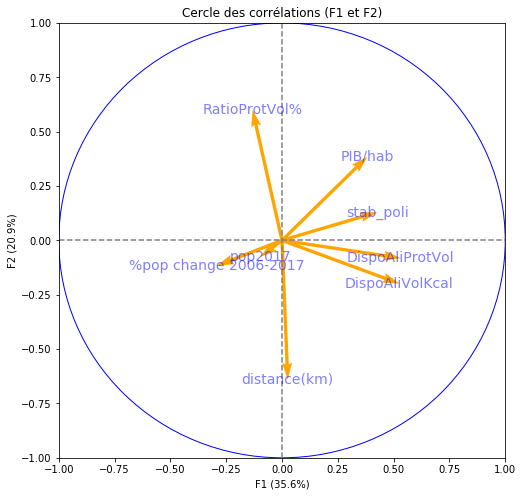

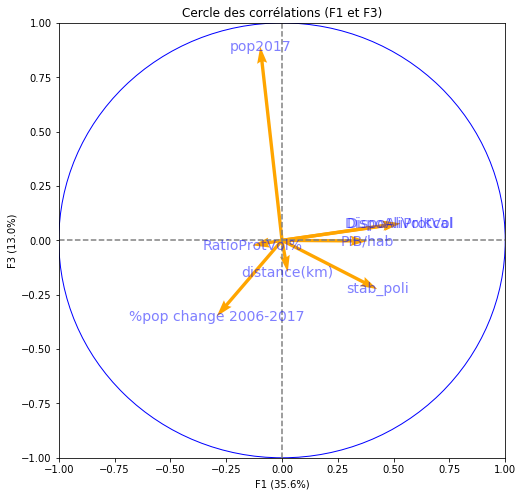

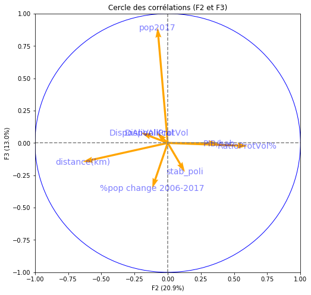

```python
pcs = pca.components_
display_circles(pcs,n_comp , pca, [(0,1),(0,2),(1,2)], labels = np.array(nom_variable))
```

```python
# Fonction qui permet de projeter les individus sur les dimensions
def display_factorial_planes(X_projected, n_comp, pca, axis_ranks, labels=None, alpha=1, illustrative_var=None):
    for d1,d2 in axis_ranks:
        if d2 < n_comp:

            # initialisation de la figure
            fig = plt.figure(figsize=(8,8))

            # affichage des points
            if illustrative_var is None:
                plt.scatter(X_projected[:, d1], X_projected[:, d2], alpha=alpha)
            else:
                illustrative_var = np.array(illustrative_var)
                for value in np.unique(illustrative_var):
                    selected = np.where(illustrative_var == value)
                    plt.scatter(X_projected[selected, d1], X_projected[selected, d2], alpha=alpha, label=value)
                plt.legend()

            # affichage des labels des points
            if labels is not None:
                for i,(x,y) in enumerate(X_projected[:,[d1,d2]]):
                    plt.text(x, y, labels[i],
                              fontsize='14', ha='center',va='center')

            # détermination des limites du graphique
            boundary = np.max(np.abs(X_projected[:, [d1,d2]])) * 1.1
            plt.xlim([-boundary,boundary])
            plt.ylim([-boundary,boundary])

            # affichage des lignes horizontales et verticales
            plt.plot([-100, 100], [0, 0], color='grey', ls='--')
            plt.plot([0, 0], [-100, 100], color='grey', ls='--')

            # nom des axes, avec le pourcentage d'inertie expliqué
            plt.xlabel('F{} ({}%)'.format(d1+1, round(100*pca.explained_variance_ratio_[d1],1)))
            plt.ylabel('F{} ({}%)'.format(d2+1, round(100*pca.explained_variance_ratio_[d2],1)))

            plt.title("Projection des individus (sur F{} et F{})".format(d1+1, d2+1))
            plt.show(block=False)
```

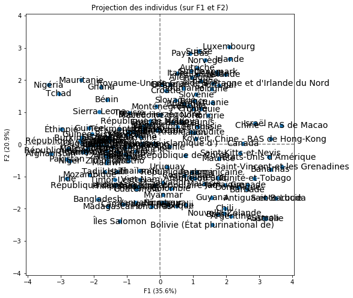

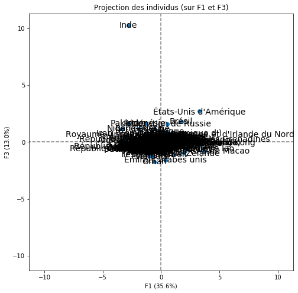

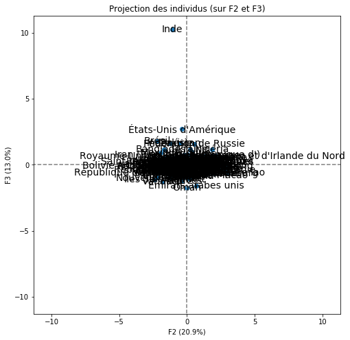

```python
# Projection des individus
X_projected = pca.transform(X_scaled)
display_factorial_planes(X_projected, n_comp, pca, [(0,1),(0,2),(1,2)], labels = np.array(names))
plt.figure()
plt.show()
```

### Enlever les outliers!!!

```python
# On enlever les outliers
df1_outliers= ['Inde','États-Unis d\'Amérique','Brésil']
```

```python
df2 = df1.drop(df1_outliers)
```

```python
df2
```

| Zone | pop2017 | %pop change 2006-2017 | RatioProtVol% | DispoAliVolKcal | DispoAliProtVol | PIB/hab | stab_poli | distance(km) |
| --- | --- | --- | --- | --- | --- | --- | --- | --- |
| Afghanistan | 36296.113 | 37.313380 | 10.50 | 6.0 | 0.63 | 2058.4 | -2.80 | 5590.381 |
| Afrique du Sud | 57009.756 | 17.571442 | 9.82 | 149.0 | 14.63 | 12701.3 | -0.28 | 8692.812 |
| Albanie | 2884.169 | -5.839072 | 7.53 | 59.0 | 4.44 | 12771.0 | 0.38 | 1603.534 |
| Algérie | 41389.189 | 23.031974 | 8.88 | 24.0 | 2.13 | 11737.4 | -0.92 | 1340.390 |
| Allemagne | 82658.409 | 1.455935 | 11.03 | 67.0 | 7.39 | 52952.9 | 0.59 | 880.187 |
| ... | ... | ... | ... | ... | ... | ... | ... | ... |
| Égypte | 96442.591 | 25.455959 | 9.25 | 61.0 | 5.64 | 11014.5 | -1.42 | 3215.215 |
| Émirats arabes unis | 9487.203 | 78.997954 | 10.14 | 88.0 | 8.92 | 67183.6 | 0.62 | 5249.535 |
| Équateur | 16785.361 | 19.389022 | 7.43 | 87.0 | 6.46 | 11617.9 | -0.07 | 9367.098 |
| Éthiopie | 106399.924 | 35.559944 | 12.00 | 2.0 | 0.24 | 2021.6 | -1.68 | 5582.502 |
| Îles Salomon | 636.039 | 32.211201 | 8.16 | 19.0 | 1.55 | 2663.9 | 0.20 | 15178.200 |

159 rows × 8 columns

```python
len(df2)
```

```
159
```

# Checking the correlation between variables

# corrMatrix = df2.corr()

# sns.set(rc = {'figure.figsize':(15,8)})

# sns.heatmap(corrMatrix, annot=True)

# plt.show()

## 3. Cluster et dendrogram

```python
from scipy.cluster.hierarchy import dendrogram
from scipy.cluster.hierarchy import linkage, fcluster
```

```python
def plot_dendrogram(Y, names):
    plt.figure(figsize=(30,15))
    plt.title('Clustering Dendrogram')
    plt.xlabel('Distance')
    plt.axhline(y =12, linewidth = 1.5, c = 'red', linestyle = 'dashed')
    dendrogram(
        Y,
        labels = names,
        orientation = 'top',
    )
    plt.show()
```

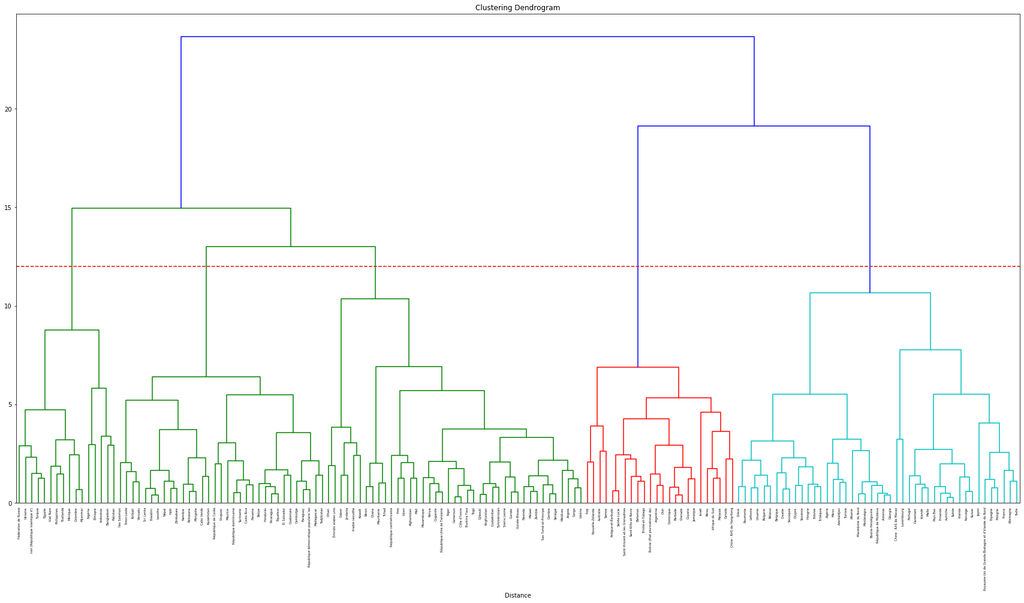

```python
# redefinition data

X = df2.values
names = df2.index

# scaled data
std_scale = preprocessing.StandardScaler().fit(X)
X_scaled = std_scale.transform(X)

# Clustering
Y = linkage(X_scaled, method = 'ward')

# Affichage du dendrogramme
plot_dendrogram(Y, names)

#save fig
plt.savefig('dend.png', dpi=300)
```

# import scipy.cluster.hierarchy as shc

# max_d = 15

# plt.figure(figsize=(20,7))

# Y = shc.linkage(df2, 'ward')

# shc.dendrogram(Y, color_threshold=max_d, labels=df2.index)

# plt.axhline(y=max_d, c='grey', lw=1, linestyle='dashed')

```python
def plot_dendrogram(Y, names):
    plt.figure(figsize=(15,10))
    plt.title('Hierarchical Clustering Dendrogram')
    plt.xlabel('Distance')
    plt.axhline(y =12, linewidth = .5, c = "dimgray", linestyle = "--")
    dendrogram(
        Y,
        labels = names,
        orientation = "top",
    )
    plt.show()
```

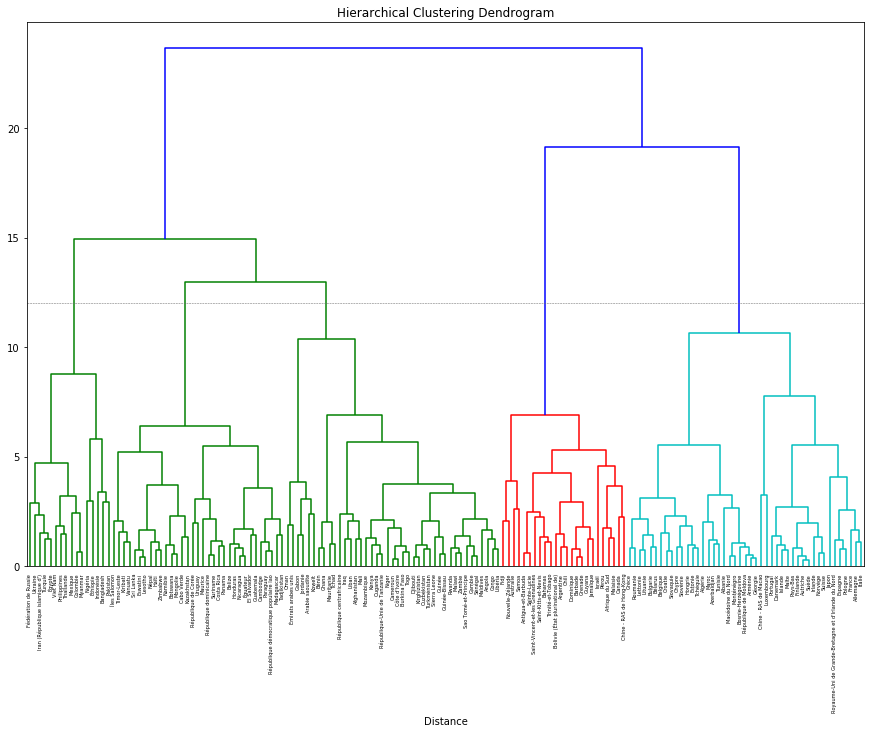

```python
# préparation des données pour le clustering
X = df2.values
names = df2.index

# Centrage et Réduction
std_scale = preprocessing.StandardScaler().fit(X)
X_scaled = std_scale.transform(X)

# Clustering hiérarchique
Z = linkage(X_scaled, 'ward')

# Affichage du dendrogramme
plot_dendrogram(Z, names)
```

```python
# Découpe du dendrogramme en 6 clusters
clusters = fcluster(Z, 6, criterion='maxclust')

# Création d'un df avec une colonne cluster et une colonne zone
groupes = pd.DataFrame({"cluster": clusters, "Zone": names})
print(groupes)
```

```
     cluster                 Zone
0          3          Afghanistan
1          4       Afrique du Sud
2          5              Albanie
3          5              Algérie
4          6            Allemagne
..       ...                  ...
154        1               Égypte
155        3  Émirats arabes unis
156        2             Équateur
157        1             Éthiopie
158        2         Îles Salomon

[159 rows x 2 columns]
```

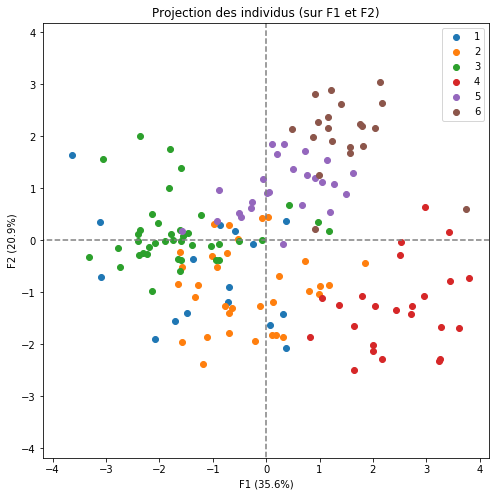

```python
# Projection des individus sur F1 et F2
X_projected = pca.transform(X_scaled)
display_factorial_planes(X_projected, n_comp, pca, [(0,1)], labels=None, illustrative_var=clusters)
plt.show()
```

```python
# Je tri les pays par cluster
groupes.sort_values(by=['cluster']).head()
```

|  | cluster | Zone |
| --- | --- | --- |
| 141 | 1 | Thaïlande |
| 108 | 1 | Pakistan |
| 101 | 1 | Nigéria |
| 48 | 1 | Fédération de Russie |
| 97 | 1 | Myanmar |

```python
# Affichage du nombre de pays par cluster
groupes['cluster'].value_counts()
```

```
3    41
2    33
5    25
4    24
6    20
1    16
Name: cluster, dtype: int64
```

```python
# Mise à l'échelle des données
df3 = pd.DataFrame(X_scaled, columns= list(nom_variable), index=df2.index)
```

```python
df3.head()
```

| Zone | pop2017 | %pop change 2006-2017 | RatioProtVol% | DispoAliVolKcal | DispoAliProtVol | PIB/hab | stab_poli | distance(km) |
| --- | --- | --- | --- | --- | --- | --- | --- | --- |
| Afghanistan | 0.289196 | 1.147836 | 0.367136 | -1.125869 | -1.163230 | -0.878625 | -3.183416 | -0.068775 |
| Afrique du Sud | 0.800501 | -0.021349 | -0.097891 | 1.217064 | 1.324018 | -0.364070 | -0.286523 | 0.735449 |
| Albanie | -0.535561 | -1.407800 | -1.663939 | -0.257509 | -0.486343 | -0.360700 | 0.472188 | -1.102261 |
| Algérie | 0.414915 | 0.302042 | -0.740723 | -0.830955 | -0.896739 | -0.410672 | -1.022242 | -1.170474 |
| Allemagne | 1.433624 | -0.975765 | 0.729583 | -0.126436 | 0.037756 | 1.581984 | 0.713595 | -1.289770 |

```python
groupes.head()
```

|  | cluster | Zone |
| --- | --- | --- |
| 0 | 3 | Afghanistan |
| 1 | 4 | Afrique du Sud |
| 2 | 5 | Albanie |
| 3 | 5 | Algérie |
| 4 | 6 | Allemagne |

```python
# Jointure de la colonne cluster dans df3
df3_clusters = pd.merge(df3, groupes, on='Zone')
```

```python
df3_clusters.head()
```

|  | Zone | pop2017 | %pop change 2006-2017 | RatioProtVol% | DispoAliVolKcal | DispoAliProtVol | PIB/hab | stab_poli | distance(km) | cluster |
| --- | --- | --- | --- | --- | --- | --- | --- | --- | --- | --- |
| 0 | Afghanistan | 0.289196 | 1.147836 | 0.367136 | -1.125869 | -1.163230 | -0.878625 | -3.183416 | -0.068775 | 3 |
| 1 | Afrique du Sud | 0.800501 | -0.021349 | -0.097891 | 1.217064 | 1.324018 | -0.364070 | -0.286523 | 0.735449 | 4 |
| 2 | Albanie | -0.535561 | -1.407800 | -1.663939 | -0.257509 | -0.486343 | -0.360700 | 0.472188 | -1.102261 | 5 |
| 3 | Algérie | 0.414915 | 0.302042 | -0.740723 | -0.830955 | -0.896739 | -0.410672 | -1.022242 | -1.170474 | 5 |
| 4 | Allemagne | 1.433624 | -0.975765 | 0.729583 | -0.126436 | 0.037756 | 1.581984 | 0.713595 | -1.289770 | 6 |

```python
# Calcul de la moyenne des variables pour chaque cluster
df3l_clusters_moy = df3_clusters.groupby('cluster').agg(['mean'])
```

```python
df3l_clusters_moy
```

| cluster | pop2017 mean | %pop change 2006-2017 mean | RatioProtVol% mean | DispoAliVolKcal mean | DispoAliProtVol mean | PIB/hab mean | stab_poli mean | distance(km) mean |
| --- | --- | --- | --- | --- | --- | --- | --- | --- |
| 1 | 2.284135 | -0.122619 | -0.167987 | -0.238053 | -0.293137 | -0.405612 | -1.308913 | 0.203186 |
| 2 | -0.380622 | -0.031551 | -0.611411 | -0.347870 | -0.433422 | -0.448060 | 0.178179 | 0.833761 |
| 3 | -0.203714 | 1.232243 | 0.444362 | -0.703878 | -0.688269 | -0.537717 | -0.651578 | -0.157516 |
| 4 | -0.316538 | -0.422637 | -0.699406 | 1.832152 | 1.685631 | 0.162021 | 0.669050 | 0.936845 |
| 5 | -0.393701 | -1.025805 | 0.087846 | -0.146753 | -0.096129 | 0.152948 | 0.162266 | -1.055131 |
| 6 | 0.090305 | -0.586523 | 0.961755 | 0.192236 | 0.458012 | 1.780499 | 1.083179 | -1.020646 |

# Création d'une clustermap

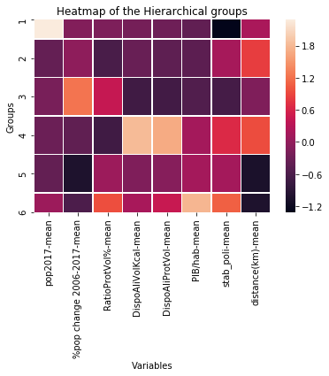

```python
import seaborn as sns

ax = sns.heatmap(df3l_clusters_moy, linewidth=0.5)
ax.set(title="Heatmap of the Hierarchical groups",
      xlabel="Variables",
      ylabel="Groups",)
plt.show()
```

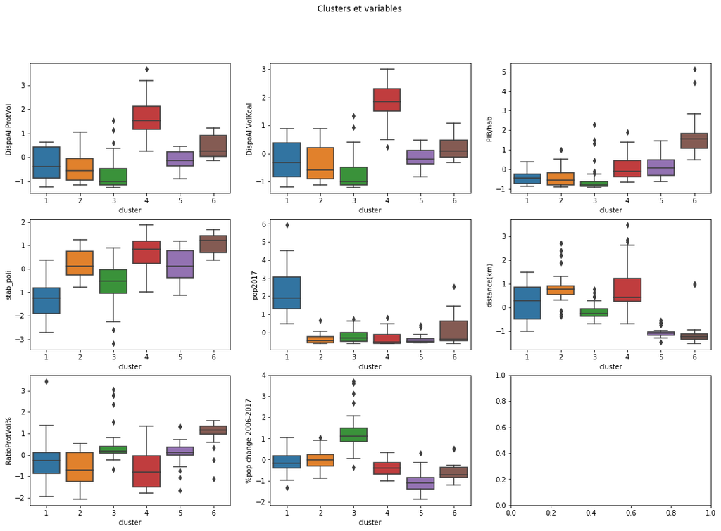

```python
# Création de boxplot
fig, axes = plt.subplots(3, 3, figsize=(18, 12))

fig.suptitle('Clusters et variables')

sns.boxplot(ax=axes[0, 0], data=df3_clusters, x='cluster', y='DispoAliProtVol')
sns.boxplot(ax=axes[0, 1], data=df3_clusters, x='cluster', y='DispoAliVolKcal')
sns.boxplot(ax=axes[0, 2], data=df3_clusters, x='cluster', y='PIB/hab')
sns.boxplot(ax=axes[1, 0], data=df3_clusters, x='cluster', y='stab_poli')
sns.boxplot(ax=axes[1, 1], data=df3_clusters, x='cluster', y='pop2017')
sns.boxplot(ax=axes[1, 2], data=df3_clusters, x='cluster', y='distance(km)')
sns.boxplot(ax=axes[2, 0], data=df3_clusters, x='cluster', y='RatioProtVol%')
sns.boxplot(ax=axes[2, 1], data=df3_clusters, x='cluster', y='%pop change 2006-2017')

plt.show()
```

### Choisie les pays désirés

```python
# Affiche des pays du cluster 4
cluster_4 = df3_clusters.loc[df3_clusters['cluster']==4]
```

```python
cluster_4
```

|  | Zone | pop2017 | %pop change 2006-2017 | RatioProtVol% | DispoAliVolKcal | DispoAliProtVol | PIB/hab | stab_poli | distance(km) | cluster |
| --- | --- | --- | --- | --- | --- | --- | --- | --- | --- | --- |
| 1 | Afrique du Sud | 0.800501 | -0.021349 | -0.097891 | 1.217064 | 1.324018 | -0.364070 | -0.286523 | 0.735449 | 4 |
| 6 | Antigua-et-Barbuda | -0.604399 | -0.150982 | -1.622907 | 2.822711 | 2.055979 | -0.018919 | 0.897525 | 0.221138 | 4 |
| 8 | Argentine | 0.477810 | -0.361487 | -1.718648 | 1.921583 | 1.267167 | 0.162712 | 0.230780 | 1.352257 | 4 |
| 10 | Australie | 0.000104 | 0.108934 | -0.939044 | 2.134577 | 1.853446 | 1.365857 | 1.058464 | 2.872823 | 4 |
| 13 | Bahamas | -0.597331 | -0.154549 | -0.686014 | 2.380339 | 2.226533 | 0.776785 | 1.173420 | 0.350926 | 4 |
| 15 | Barbade | -0.599689 | -0.875128 | -1.568198 | 1.987119 | 1.395082 | -0.214788 | 1.150428 | 0.266132 | 4 |
| 18 | Bolivie (État plurinational de) | -0.330465 | 0.070992 | -1.773357 | 1.970735 | 1.279603 | -0.570880 | -0.286523 | 1.093865 | 4 |
| 28 | Canada | 0.299958 | -0.298402 | -0.672337 | 1.298985 | 1.181889 | 1.357856 | 1.299871 | -0.052488 | 4 |
| 29 | Chili | -0.150822 | -0.295762 | -1.404071 | 1.528363 | 1.085953 | 0.204948 | 0.518170 | 1.505494 | 4 |
| 30 | Chine - RAS de Hong-Kong | -0.426402 | -0.622964 | 0.579133 | 1.757741 | 2.219427 | 1.915401 | 0.989490 | 0.980847 | 4 |
| 40 | Dominique | -0.604991 | -1.000018 | -1.581875 | 1.626668 | 1.089506 | -0.431626 | 1.414827 | 0.251630 | 4 |
| 45 | Fidji | -0.585095 | -0.707245 | -0.186794 | 0.234015 | 0.256278 | -0.328873 | 0.771073 | 2.783906 | 4 |
| 52 | Grenade | -0.604018 | -0.726685 | -1.239943 | 1.970735 | 1.549647 | -0.194072 | 1.196411 | 0.327813 | 4 |
| 57 | Guyana | -0.587619 | -0.832831 | -1.704971 | 1.479211 | 0.915399 | -0.397715 | -0.010628 | 0.379603 | 4 |
| 67 | Israël | -0.403260 | 0.323786 | 1.351899 | 2.593333 | 3.667360 | 0.899374 | -0.987755 | -0.667189 | 4 |
| 69 | Jamaïque | -0.534655 | -0.704120 | -0.774916 | 1.692205 | 1.515891 | -0.514005 | 0.391718 | 0.487083 | 4 |
| 85 | Malaisie | 0.161047 | 0.046147 | -0.528725 | 1.069607 | 1.009559 | 0.310867 | 0.173302 | 1.187429 | 4 |
| 103 | Nouvelle-Zélande | -0.490687 | -0.331729 | -0.836464 | 0.496162 | 0.355768 | 1.066235 | 1.863156 | 3.475723 | 4 |
| 115 | Pérou | 0.169431 | -0.357633 | 0.510747 | 1.675820 | 2.093288 | -0.373488 | -0.263531 | 1.143804 | 4 |
| 125 | Saint-Kitts-et-Nevis | -0.605470 | -0.473246 | 0.107268 | 1.675820 | 1.906744 | 0.247948 | 0.782569 | 0.234596 | 4 |
| 126 | Saint-Vincent-et-les Grenadines | -0.604044 | -0.995243 | 0.230363 | 2.789943 | 3.207219 | -0.386126 | 1.058464 | 0.293962 | 4 |
| 127 | Sainte-Lucie | -0.602288 | -0.504317 | -1.479296 | 3.002937 | 2.301151 | -0.255560 | 1.173420 | 0.271687 | 4 |
| 128 | Samoa | -0.601933 | -0.588009 | 0.073074 | 2.347571 | 2.626270 | -0.664814 | 1.391836 | 2.632737 | 4 |
| 144 | Trinité-et-Tobago | -0.572590 | -0.691444 | -0.822787 | 2.298418 | 2.071969 | 0.295449 | 0.357231 | 0.355042 | 4 |

```python
# Affiche des pays du cluster 6
cluster_6 = df3_clusters.loc[df3_clusters['cluster']==6]
```

```python
cluster_6
```

|  | Zone | pop2017 | %pop change 2006-2017 | RatioProtVol% | DispoAliVolKcal | DispoAliProtVol | PIB/hab | stab_poli | distance(km) | cluster |
| --- | --- | --- | --- | --- | --- | --- | --- | --- | --- | --- |
| 4 | Allemagne | 1.433624 | -0.975765 | 0.729583 | -0.126436 | 0.037756 | 1.581984 | 0.713595 | -1.289770 | 6 |
| 11 | Autriche | -0.389040 | -0.679890 | 1.064677 | -0.159204 | 0.055522 | 1.640827 | 1.242393 | -1.249602 | 6 |
| 31 | Chine - RAS de Macao | -0.591387 | 0.482595 | -1.130525 | 1.069607 | 0.791036 | 5.122506 | 1.679226 | 0.971113 | 6 |
| 38 | Danemark | -0.465257 | -0.748714 | 1.105708 | 0.365088 | 0.719972 | 1.698201 | 1.035472 | -1.251555 | 6 |
| 42 | Espagne | 0.544712 | -0.807921 | 1.372415 | 0.479777 | 0.936718 | 0.932970 | 0.357231 | -1.244544 | 6 |
| 46 | Finlande | -0.470709 | -0.799533 | 1.160417 | -0.110052 | 0.133692 | 1.321740 | 1.276880 | -1.022523 | 6 |
| 47 | France | 0.993848 | -0.741019 | -0.227825 | 0.250399 | 0.265161 | 1.177037 | 0.357231 | -1.504974 | 6 |
| 65 | Irlande | -0.489423 | -0.330337 | 1.044161 | 0.397857 | 0.746621 | 2.824639 | 1.184915 | -1.316207 | 6 |
| 66 | Islande | -0.598500 | -0.376866 | 1.310867 | 0.479777 | 0.918952 | 1.711825 | 1.587262 | -0.938642 | 6 |
| 68 | Italie | 0.890943 | -0.846404 | 1.413447 | -0.159204 | 0.114150 | 1.032189 | 0.391718 | -1.230223 | 6 |
| 70 | Japon | 2.540582 | -1.104417 | 0.579133 | -0.126436 | 0.011107 | 1.002479 | 1.311367 | 1.003180 | 6 |
| 82 | Luxembourg | -0.592144 | 0.544487 | 0.332943 | -0.093668 | 0.005777 | 4.451640 | 1.564270 | -1.442993 | 6 |
| 89 | Malte | -0.595945 | -0.601339 | 1.598090 | 0.463393 | 0.975803 | 1.083582 | 1.472306 | -1.063596 | 6 |
| 102 | Norvège | -0.476018 | -0.272007 | 1.351899 | -0.060900 | 0.231406 | 2.118537 | 1.380341 | -1.169826 | 6 |
| 111 | Pays-Bas | -0.186592 | -0.852602 | 1.563897 | -0.323046 | -0.077724 | 1.685239 | 1.092950 | -1.407009 | 6 |
| 113 | Pologne | 0.330099 | -1.123951 | 1.331383 | 0.709156 | 1.220975 | 0.475393 | 0.633126 | -1.163271 | 6 |
| 114 | Portugal | -0.352788 | -1.204843 | 1.180933 | 0.561698 | 0.988239 | 0.619477 | 1.322863 | -1.141320 | 6 |
| 117 | Royaume-Uni de Grande-Bretagne et d'Irlande du... | 1.040377 | -0.486897 | 1.064677 | 0.774692 | 1.222751 | 1.233487 | 0.414710 | -1.429035 | 6 |
| 134 | Suisse | -0.398028 | -0.269604 | 1.256158 | -0.323046 | -0.122139 | 2.362826 | 1.483801 | -1.404894 | 6 |
| 136 | Suède | -0.362258 | -0.535441 | 1.133063 | -0.224741 | -0.015543 | 1.533400 | 1.161924 | -1.117228 | 6 |